# Biostat 203B Homework 2

Due Feb 12 @ 11:59PM

Olivia Golston

```r
knitr::opts_chunk$set(echo = TRUE, cache = TRUE)
library(tidyverse)
library(data.table)
library(lubridate)
os <- sessionInfo()$running
if (str_detect(os, "Linux")) {
  mimic_path <- "/usr/203b-data/mimic-iv"
} else if (str_detect(os, "macOS")) {
  mimic_path <- "/Users/huazhou/Documents/Box Sync/MIMIC/mimic-iv-0.4"
}
```

Use tidyverse (ggpot2, dplyr) to explore the [MIMIC-IV](https://mimic-iv.mit.edu) data introduced in [homework 1](https://ucla-biostat203b-2021winter.github.io/hw/hw1/hw1.html).

```r
system(str_c("tree -s -L 2 ", shQuote(mimic_path)), intern = TRUE)
```

```
##  [1] "/usr/203b-data/mimic-iv"
##  [2] "├── [         78]  core"
##  [3] "│   ├── [   17224843]  admissions.csv.gz"
##  [4] "│   ├── [    2884996]  patients.csv.gz"
##  [5] "│   └── [   51188147]  transfers.csv.gz"
##  [6] "├── [       4096]  hosp"
##  [7] "│   ├── [     430049]  d_hcpcs.csv.gz"
##  [8] "│   ├── [   26575586]  diagnoses_icd.csv.gz"
##  [9] "│   ├── [     723633]  d_icd_diagnoses.csv.gz"
## [10] "│   ├── [     564422]  d_icd_procedures.csv.gz"
## [11] "│   ├── [      14845]  d_labitems.csv.gz"
## [12] "│   ├── [   12913088]  drgcodes.csv.gz"
## [13] "│   ├── [  518077567]  emar.csv.gz"
## [14] "│   ├── [  479709397]  emar_detail.csv.gz"
## [15] "│   ├── [    1415469]  hcpcsevents.csv.gz"
```

[output cut: 20 more lines]

### Note

As with many of my classmates, I had a lot of issues with the teaching server while working on this assignment. Particularly for Questions 6-8, I wasn’t able to do as much testing and troubleshooting as I would have liked, due to very frequent crashes (and loss of environmental variables each time).

I’m also not certain whether you will be able to properly knit my file, since I’m relying mostly on a filtered down data set that I saved.

## Q1. PhysioNet credential

At this moment, you should already get credentialed on the PhysioNet. Please include a screenshot of your `Data Use Agreement for the MIMIC-IV (v0.4)`.

### Solution

Here is my Data Use Agreement:

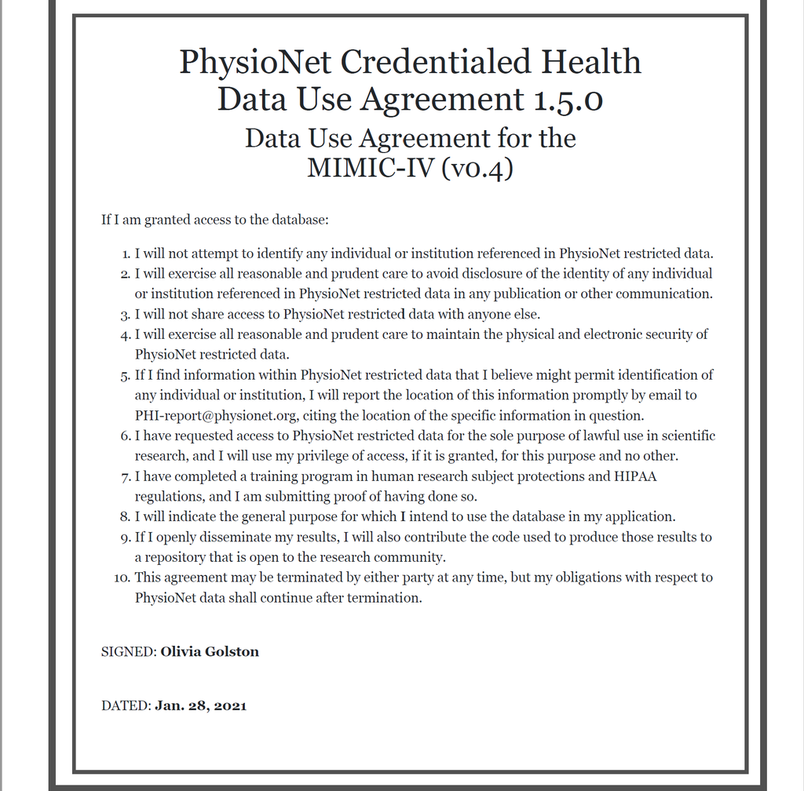

## Q2. `read.csv` (base R) vs `read_csv` (tidyverse) vs `fread` (data.table)

There are quite a few utilities in R for reading data files. Let us test the speed of reading a moderate sized compressed csv file, `admissions.csv.gz`, by three programs: `read.csv` in base R, `read_csv` in tidyverse, and `fread` in the popular data.table package. Is there any speed difference?

In this homework, we stick to the tidyverse.

### Solution

The code below records the time required to read in `admissions.csv.gz` using each of the 3 methods.

```r
file_path <- str_c(mimic_path, "/core/admissions.csv.gz")

read.csv_time <- system.time(file1 <- read.csv(file_path))
read_csv_time <- system.time(file2 <- read_csv(file_path))
fread_time <- system.time(file3 <- fread(file_path))
```

A comparison of elapsed times are displayed in the table.

| Function | Time Elapsed for Execution |
| --- | --- |
| read.csv | 48.117 |
| read_csv | 5.086 |
| fread | 4.175 |

`read.csv` is consistently the slowest, by far. `read_csv` and `fread` are similar, but `fread` tends to be a slight bit faster.

Memory is an issue for this assignment, so these variables are removed from the environment.

```r
rm(file1)
rm(file2)
rm(file3)

rm(read.csv_time)
rm(read_csv_time)
rm(fread_time)
```

## Q3. ICU stays

`icustays.csv.gz` (https://mimic-iv.mit.edu/docs/datasets/icu/icustays/) contains data about Intensive Care Units (ICU) stays. Summarize following variables using appropriate numerics or graphs:

- how many unique `stay_id`?
- how many unique `subject_id`?
- length of ICU stay
- first ICU unit
- last ICU unit

### Solution

The first step is to read in `icustays` data and examine the data structure:

```r
icu_stays <- read_csv(str_c(mimic_path, "/icu/icustays.csv.gz"))

icu_stays %>%
  print()
```

```
## # A tibble: 69,619 x 8
##    subject_id hadm_id stay_id first_careunit last_careunit intime
##         <dbl>   <dbl>   <dbl> <chr>          <chr>         <dttm>
##  1   17823467  2.76e7  3.60e7 Coronary Care… Coronary Car… 2138-05-09 05:08:00
##  2   15772648  2.61e7  3.96e7 Trauma SICU (… Trauma SICU … 2146-06-18 18:35:00
##  3   13713711  2.58e7  3.64e7 Trauma SICU (… Trauma SICU … 2157-09-15 15:30:00
##  4   13173210  2.23e7  3.82e7 Coronary Care… Coronary Car… 2178-02-12 17:13:50
##  5   10213765  2.85e7  3.98e7 Trauma SICU (… Trauma SICU … 2113-04-10 14:11:00
##  6   17530304  2.18e7  3.58e7 Trauma SICU (… Trauma SICU … 2129-03-21 07:09:00
##  7   10297774  2.04e7  3.78e7 Coronary Care… Coronary Car… 2194-05-10 21:35:40
##  8   16766597  2.12e7  3.93e7 Trauma SICU (… Trauma SICU … 2115-07-11 23:15:59
##  9   17684317  2.87e7  3.70e7 Trauma SICU (… Trauma SICU … 2148-04-14 22:03:00
## 10   15693895  2.12e7  3.48e7 Surgical Inte… Surgical Int… 2147-06-02 23:31:46
## # … with 69,609 more rows, and 2 more variables: outtime <dttm>, los <dbl>
```

#### Unique `stay_id` and `subject_id` values

We then check the number of unique `stay_id` values:

```r
icu_stays %>%
  distinct(stay_id) %>%
  nrow()
```

```
## [1] 69619
```

There are 69,619 unique `stay_id` values. This is equal to the number of observations in the original data set, because each observation has been assigned a unique `stay_id` value.

We are also interested in the number of unique `subject_id` values:

```r
icu_stays %>%
  distinct(subject_id) %>%
  nrow()
```

```
## [1] 50048
```

There are 50048 unique `subject_id` values. This is less than the total number of observations, which means that some individuals have had multiple ICU stays, and are present two or more times in the data.

```r
icu_stays %>%
  count(subject_id) %>%
  rename(number_of_stays = n) %>%
  count(number_of_stays) %>%
  rename(number_of_patients = n) %>%
  arrange(desc(number_of_stays)) %>%
  print()
```

```
## # A tibble: 28 x 2
##    number_of_stays number_of_patients
##              <int>              <int>
##  1              33                  1
##  2              30                  1
##  3              29                  1
##  4              26                  1
##  5              25                  1
##  6              24                  1
##  7              23                  2
##  8              22                  2
##  9              20                  2
## 10              19                  1
## # … with 18 more rows
```

One patient has had 33 ICU stays! However, the majority of patients have a count of 1, 2, or 3 stays.

#### Length of Stay

My first attempt at a plot was hard to understand - it appeared that there were some outliers with extremely long stays. I want to investigate how common these long stays are.

```r
icu_stays %>%
  filter(los >= 50) %>%
  arrange(desc(los)) %>%
  select(los)
```

```
## # A tibble: 112 x 1
##      los
##    <dbl>
##  1  599.
##  2  294.
##  3  236.
##  4  223.
##  5  141.
##  6  134.
##  7  114.
##  8  110.
##  9  107.
## 10  103.
## # … with 102 more rows
```

Out of over 69,000 observations, only 112 had stays of 50 days or longer, and only 11 had stays of 100 days or longer.

To make the graph more interpretable, I decided to exclude these outlying values in the plot. Though they should not be ignored, they do not represent a typical ICU stay.

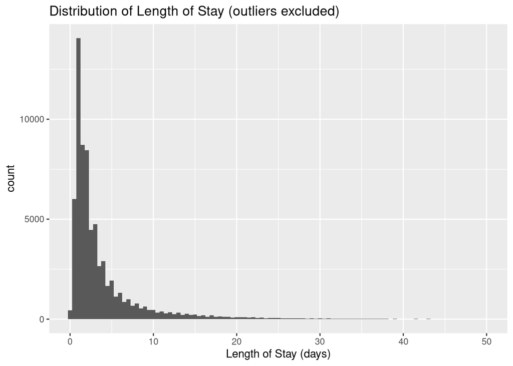

```r
icu_stays %>%
  ggplot(aes(x = los)) +
  geom_histogram(binwidth = .5) +
  coord_cartesian(xlim = c(0,50)) +
  labs(title = "Distribution of Length of Stay (outliers excluded)",
       x = "Length of Stay (days)")
```

It appears that most people stay in the ICU for less than 5 days, and very few stay beyond 10.

#### First and Last Care Unit

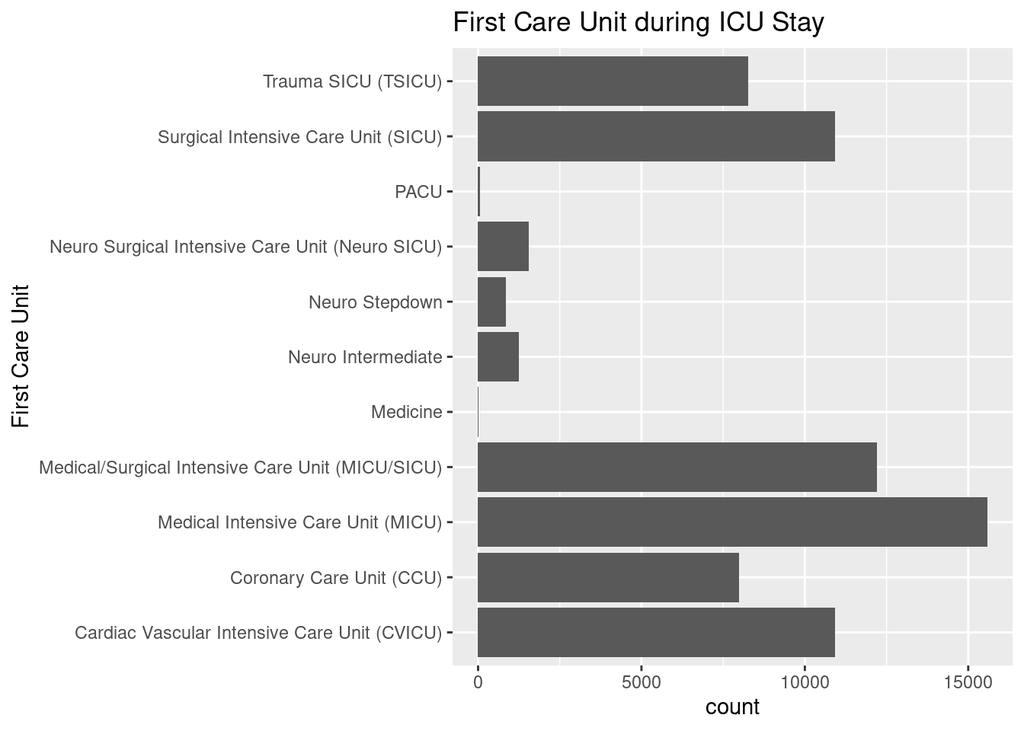

```r
icu_stays %>%
  ggplot(aes(x = first_careunit)) +
  geom_bar() +
  coord_flip() +
  labs(x = "First Care Unit", title = "First Care Unit during ICU Stay")
```

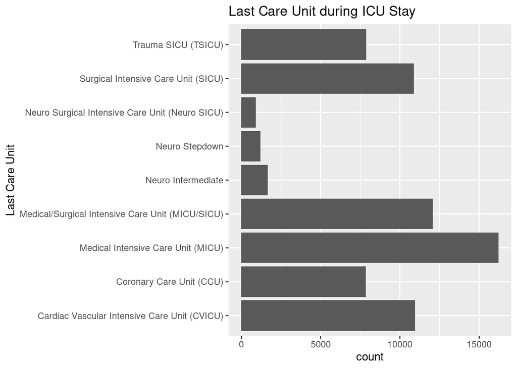

```r
icu_stays %>%
  ggplot(aes(x = last_careunit)) +
  geom_bar() +
  coord_flip() +
  labs(x = "Last Care Unit", title = "Last Care Unit during ICU Stay")
```

I’m curious how the distribution of first care units differs from last care unit, so I plot the counts at both time points side-by-side.

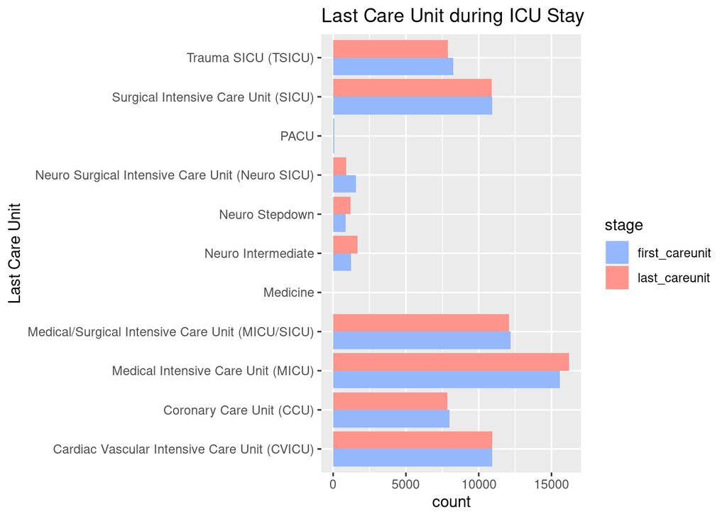

```r
icu_stays %>%
  pivot_longer(cols = c(first_careunit, last_careunit),
               names_to = "stage",
               values_to = "unit") %>%
  ggplot() +
  geom_bar(aes(x = unit, fill = stage), position = "dodge") +
  coord_flip() +
  labs(x = "Last Care Unit", title = "Last Care Unit during ICU Stay") +
  scale_fill_manual(values = c("#95b8fc", "#ff948d"))
```

There aren’t any major differences, though one trend is that neuro patients seem to be more likely to be admitted to the Neuro SICU and more likely to from the Neuro Stepdown or Neuro Intermediate units.

## Q4. `admission` data

Information of the patients admitted into hospital is available in `ADMISSION.csv.gz`. See https://mimic-iv.mit.edu/docs/datasets/core/admissions/ for details of each field in this file. Summarize following variables using appropriate graphs. Explain any patterns you observe.

- admission year
- admission month
- admission month day
- admission week day
- admission hour (anything unusual?)
- number of deaths in each year
- admission type
- number of admissions per patient
- admission location
- discharge location
- insurance
- language
- martial status
- ethnicity
- death

Note it is possible that one patient (uniquely identified by the `SUBJECT_ID`) is admitted into hospital multiple times. When summarizing some demographic information, it makes sense to summarize based on unique patients.

### Solution

First, we need to read in the admissions data. This dataset will have all admissions:

```r
admissions <- read_csv(str_c(mimic_path, "/core/admissions.csv.gz"))

admissions %>%
  print()
```

```
## # A tibble: 524,520 x 15
##    subject_id hadm_id admittime           dischtime
##         <dbl>   <dbl> <dttm>              <dttm>
##  1   12427812  2.16e7 2184-01-06 11:51:00 2184-01-10 11:45:00
##  2   14029832  2.21e7 2120-01-18 01:28:00 2120-01-20 16:13:00
##  3   14495017  2.25e7 2175-01-28 15:41:00 2175-01-29 16:00:00
##  4   13676048  2.39e7 2193-01-19 05:27:00 2193-01-24 18:59:00
##  5   13831972  2.78e7 2131-01-27 04:03:00 2131-01-27 05:39:00
##  6   18523038  2.54e7 2142-08-26 17:14:00 2142-08-27 10:00:00
##  7   16705931  2.06e7 2174-10-24 11:30:00 2174-10-24 18:45:00
##  8   19963742  2.50e7 2171-07-04 15:58:00 2171-07-05 13:37:00
##  9   10903424  2.26e7 2181-01-31 13:09:00 2181-01-31 13:42:00
## 10   15030422  2.20e7 2149-09-21 23:54:00 2149-09-22 03:59:00
## # … with 524,510 more rows, and 11 more variables: deathtime <dttm>,
## #   admission_type <chr>, admission_location <chr>, discharge_location <chr>,
## #   insurance <chr>, language <chr>, marital_status <chr>, ethnicity <chr>,
## #   edregtime <dttm>, edouttime <dttm>, hospital_expire_flag <dbl>
```

There are 524,520 admissions.

We also want a filtered version of the data that only contains unique patients, as identified by `subject_id`.

```r
admissions_unique <- admissions %>%
  distinct(subject_id, .keep_all = TRUE)

admissions_unique %>%
  nrow()
```

```
## [1] 257366
```

Though there were 524,520 admissions, there are only 257,366 unique patients in the data.

#### Admission year

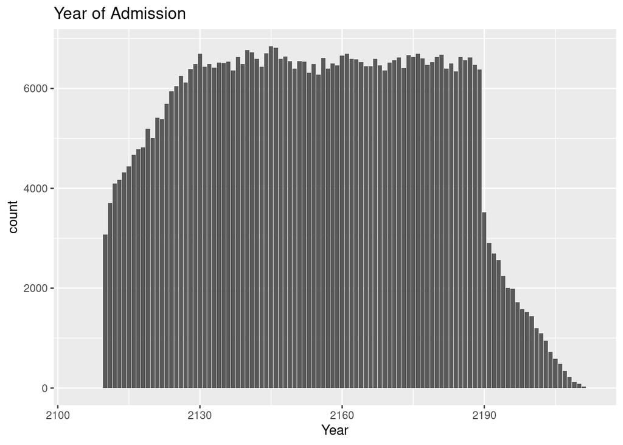

```r
ggplot(data = admissions) +
  geom_bar(aes(year(admittime))) +
  labs(x = "Year", title = "Year of Admission")
```

These admission times are all in the future! This is because the date information is shifted for each patient, to protect their privacy.

#### Admission month

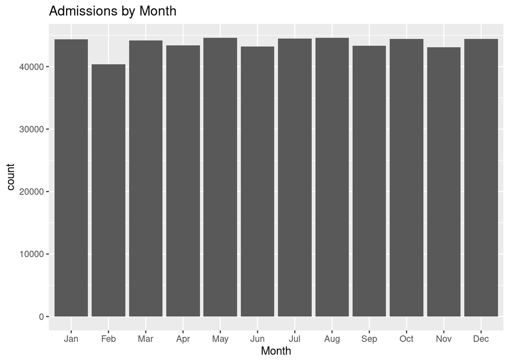

```r
ggplot(data = admissions) +
  geom_bar(aes(month(admittime, label = T))) +
  labs(title = "Admissions by Month", x = "Month")
```

The admissions per month seem concordant with the number of days in each month. For example, it makes sense that February has the least admissions, as it has only 28 days. Similarly, there is a small dip for the months with 30 days.

#### Admission month day

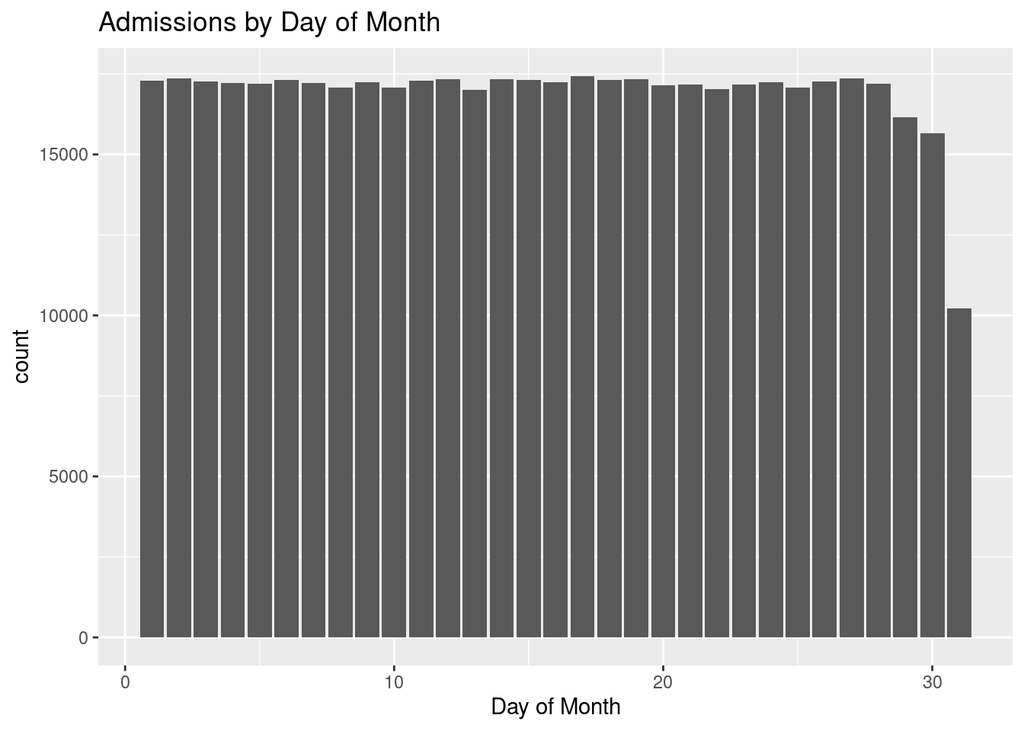

```r
ggplot(data = admissions) +
  geom_bar(aes(day(admittime))) +
  labs(title = "Admissions by Day of Month", x = "Day of Month")
```

Admissions are pretty consistent throughout the month, with the exception of a dropoff for the 29th, 30th, and 31st days of the month. This is simply because some months have only 28 or 30 days, rather than 31. Strangely, it looks like there is a small dip on the 13th of the month. I would guess that superstition about the number 13 is causing some people to avoid scheduling procedures on that day.

#### Admission week day

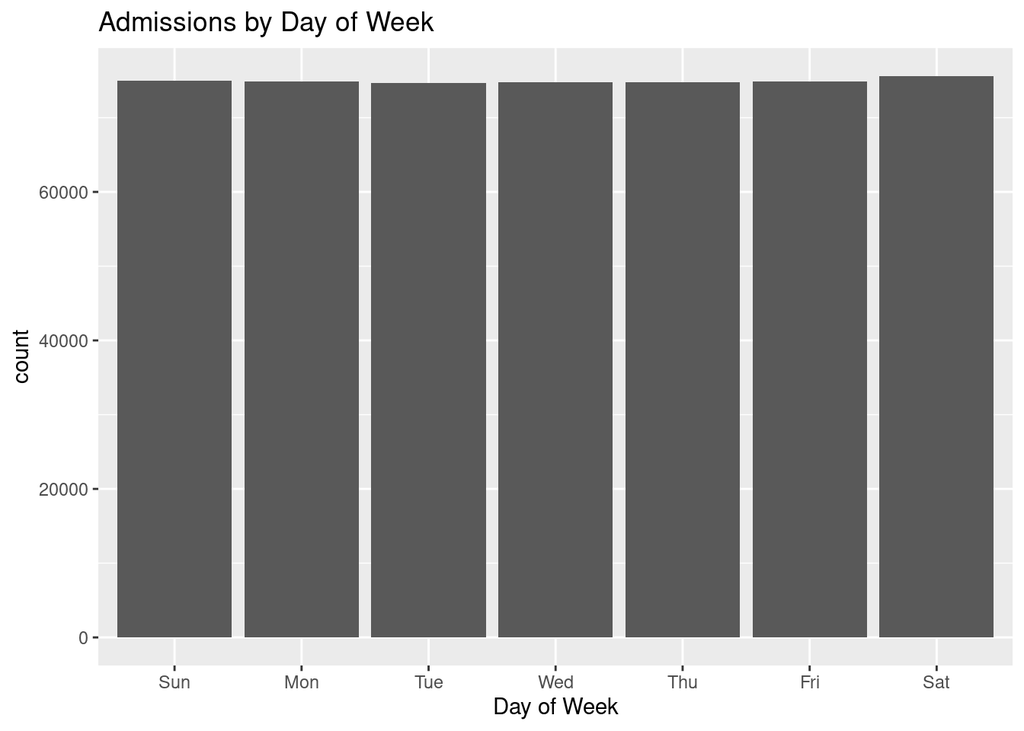

```r
ggplot(data = admissions) +
  geom_bar(aes(wday(admittime, label = T))) +
  labs(title = "Admissions by Day of Week", x = "Day of Week")
```

It looks like admissions are consistent throughout the week.

#### Admission hour

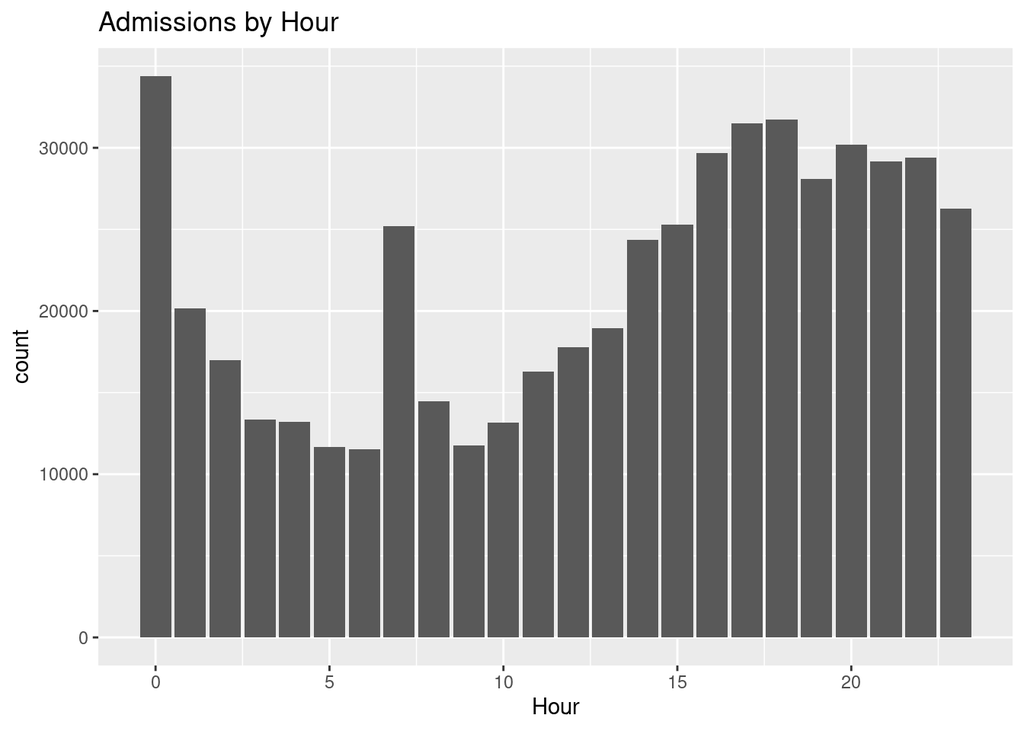

```r
ggplot(data = admissions) +
  geom_bar(aes(hour(admittime))) +
  labs(title = "Admissions by Hour", x = "Hour")
```

#### Number of deaths in each year

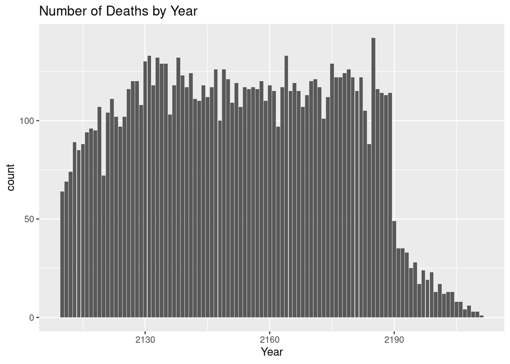

```r
admissions %>%
  filter(!is.na(deathtime)) %>%
  ggplot() +
  geom_bar(aes(year(deathtime))) +
  labs(title = "Number of Deaths by Year", x = "Year")
```

The shape roughly matches the pattern seen in the admissions by year plot, but there is more year-to-year fluctuation.

#### Admission type

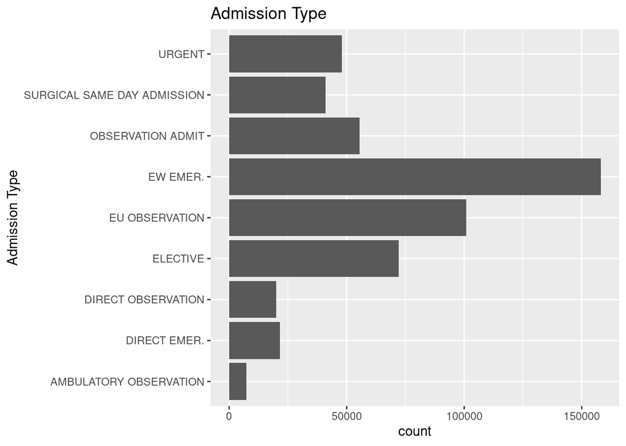

```r
admissions %>%
  ggplot() +
  geom_bar(aes(admission_type)) +
  coord_flip() +
  labs(title = "Admission Type", x = "Admission Type")
```

The most common code is `EW EMER`, which likely corresponds to some sort of emergency admission.

#### Number of admissions per patient

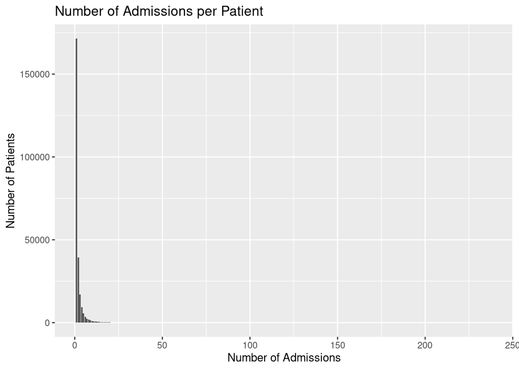

```r
admissions %>%
  count(subject_id) %>%
  ggplot() +
  geom_bar(aes(n)) +
  labs(title = "Number of Admissions per Patient", x = "Number of Admissions",
       y = "Number of Patients")
```

It’s clear that the vast majority of patients have very few admissions, but there are outliers that are making the plot harder to read.

To manually inspect:

```r
admissions %>%
  count(subject_id) %>%
  rename(number_of_stays = n) %>%
  count(number_of_stays) %>%
  rename(number_of_patients = n) %>%
  arrange(desc(number_of_stays)) %>%
  print()
```

```
## # A tibble: 95 x 2
##    number_of_stays number_of_patients
##              <int>              <int>
##  1             238                  1
##  2             185                  1
##  3             163                  1
##  4             142                  1
##  5             130                  1
##  6             129                  1
##  7              98                  1
##  8              97                  1
##  9              95                  1
## 10              94                  1
## # … with 85 more rows
```

One patient has 238 admissions!! No wonder the plot looks so terrible. On the other end of the spectrum, 171439 patients have only 1 admission. It may make sense to plot the “typical” values and the “outliers” separately.

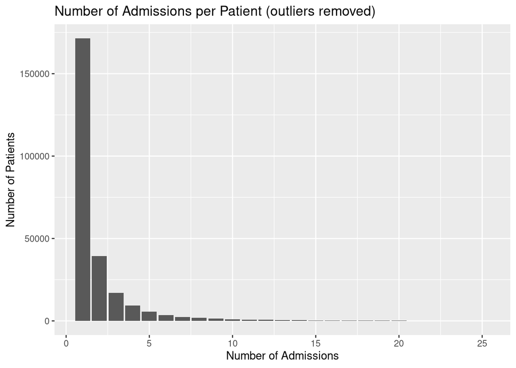

```r
admissions %>%
  count(subject_id) %>%
  filter(n <= 25) %>%
  ggplot() +
  geom_bar(aes(n)) +
  labs(title = "Number of Admissions per Patient (outliers removed)",
       x = "Number of Admissions",
       y = "Number of Patients")
```

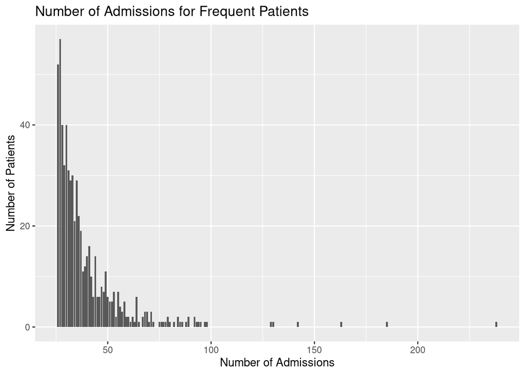

```r
admissions %>%
  count(subject_id) %>%
  filter(n > 25) %>%
  ggplot() +
  geom_bar(aes(n)) +
  labs(title = "Number of Admissions for Frequent Patients", x = "Number of Admissions",
       y = "Number of Patients")
```

Even among the “frequent fliers”, having more than 100 admissions is extremely rare.

#### Admission location

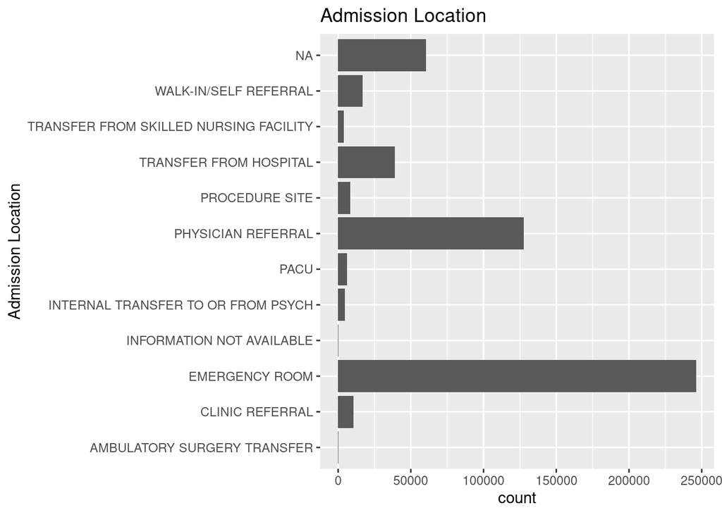

```r
admissions %>%
  ggplot() +
  geom_bar(aes(admission_location)) +
  coord_flip() +
  labs(title = "Admission Location", x = "Admission Location")
```

#### Discharge location

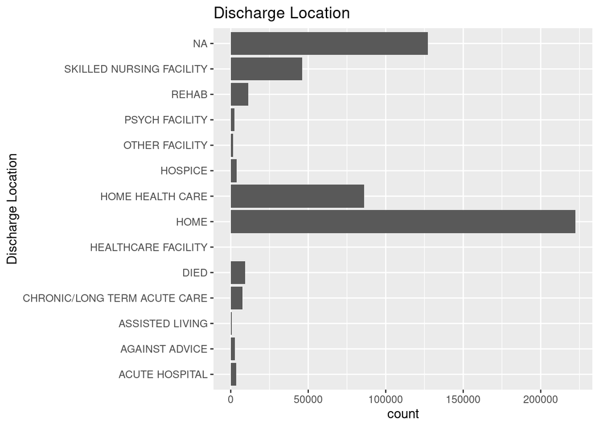

```r
admissions %>%
  ggplot() +
  geom_bar(aes(discharge_location)) +
  coord_flip() +
  labs(title = "Discharge Location", x = "Discharge Location")
```

Most patients get discharged to their home. However, there is also a very large number of `NA` values. I’m curious if there’s a systemic reason for those values.

#### Insurance

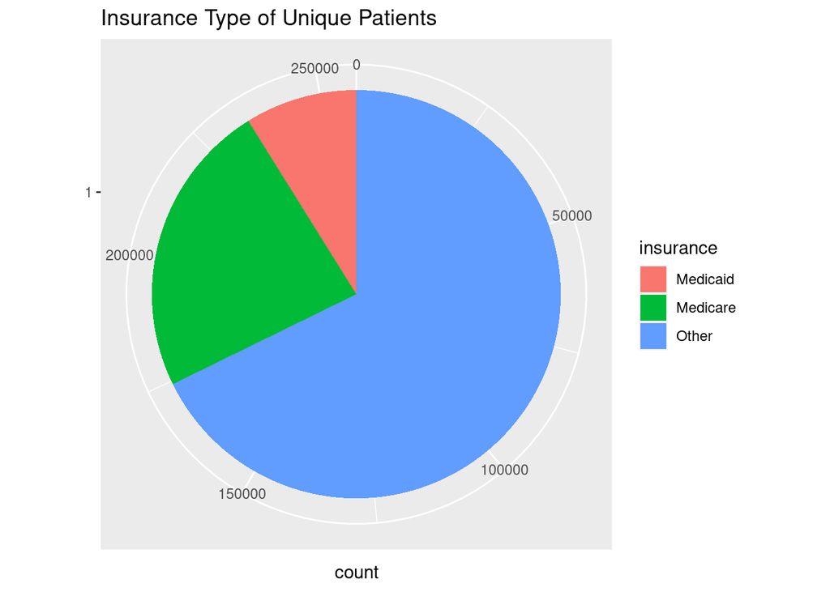

```r
admissions_unique %>%
  ggplot(aes(x = factor(1), fill = insurance)) +
  geom_bar(width = 1) +
  coord_polar("y") +
  labs(title = "Insurance Type of Unique Patients", x = NULL)
```

The majority of unique patients have non-Medicare, non-Medicaid insurance. Among the patients who do have Medicare/Medicaid, Medicare appears to be ~3 times more common.

#### Language

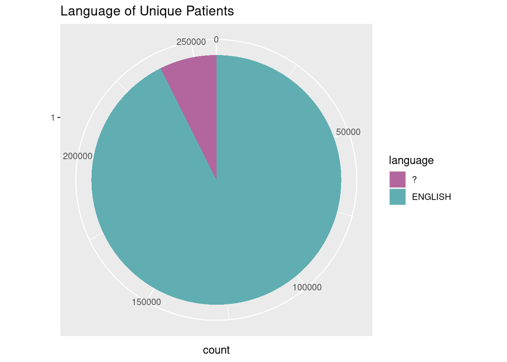

```r
admissions_unique %>%
  ggplot(aes(x = factor(1), fill = language)) +
  geom_bar(width = 1) +
  coord_polar("y") +
  labs(title = "Language of Unique Patients", x = NULL) +
  scale_fill_manual(values = c("#b3669e", "#60aeb2"))
```

This isn’t overly informative - most patients have English listed as their language. The remaining patients have `?` - it’s ambiguous if this is the coding for “language other than English” or if it could also mean “unknown.”

#### Marital status

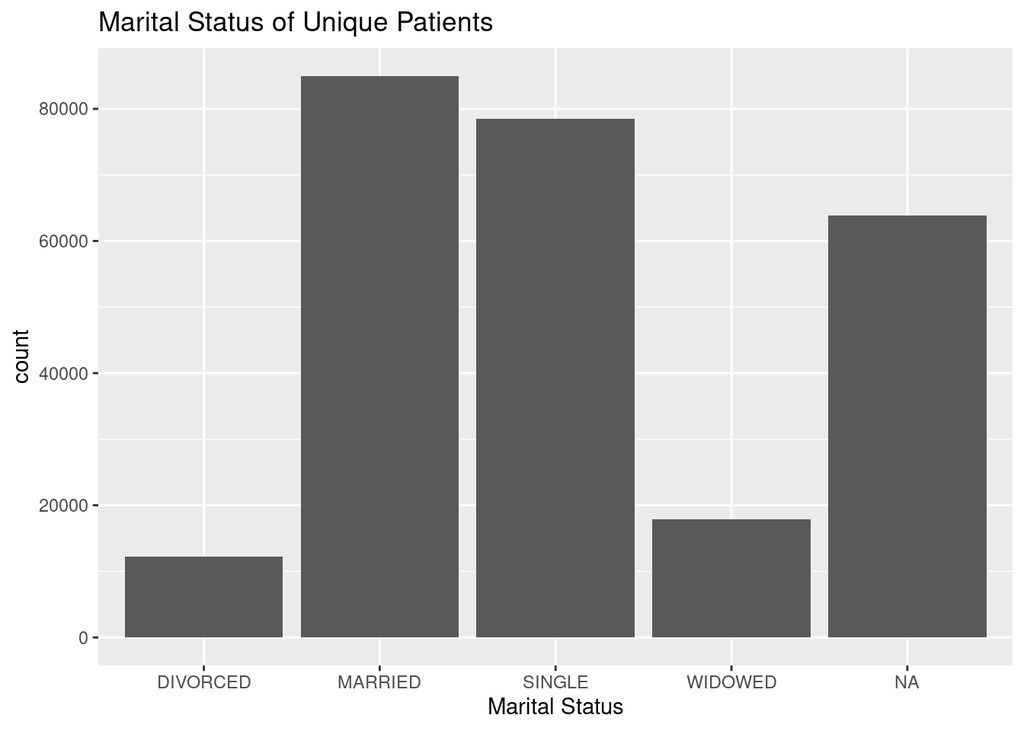

```r
admissions_unique %>%
  ggplot() +
  geom_bar(aes(marital_status)) +
  labs(title = "Marital Status of Unique Patients", x = "Marital Status")
```

Married and Single are the most common statuses, but there are also a lot of `NA` values.

#### Ethnicity

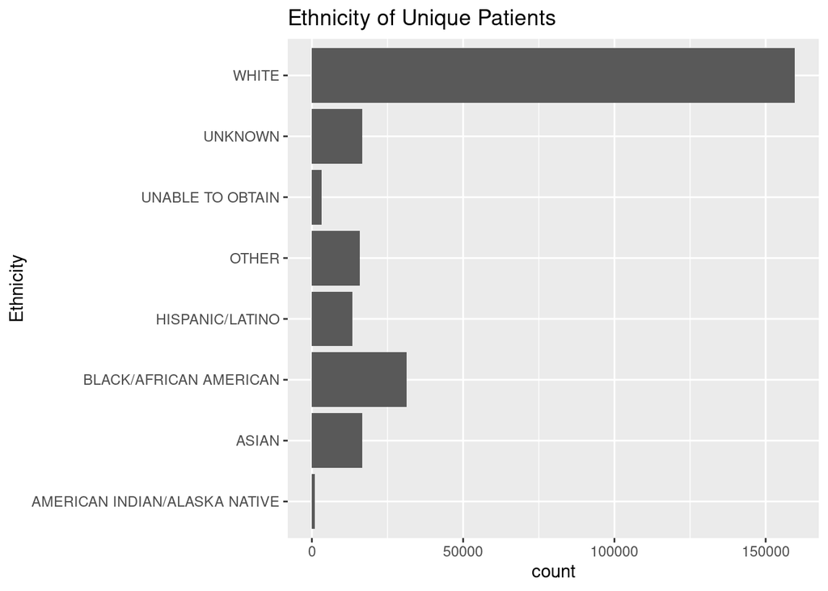

```r
admissions_unique %>%
  ggplot() +
  geom_bar(aes(ethnicity)) +
  coord_flip() +
  labs(title = "Ethnicity of Unique Patients", x = "Ethnicity")
```

The most common ethnicity is White, followed by Black/African American.

#### Death

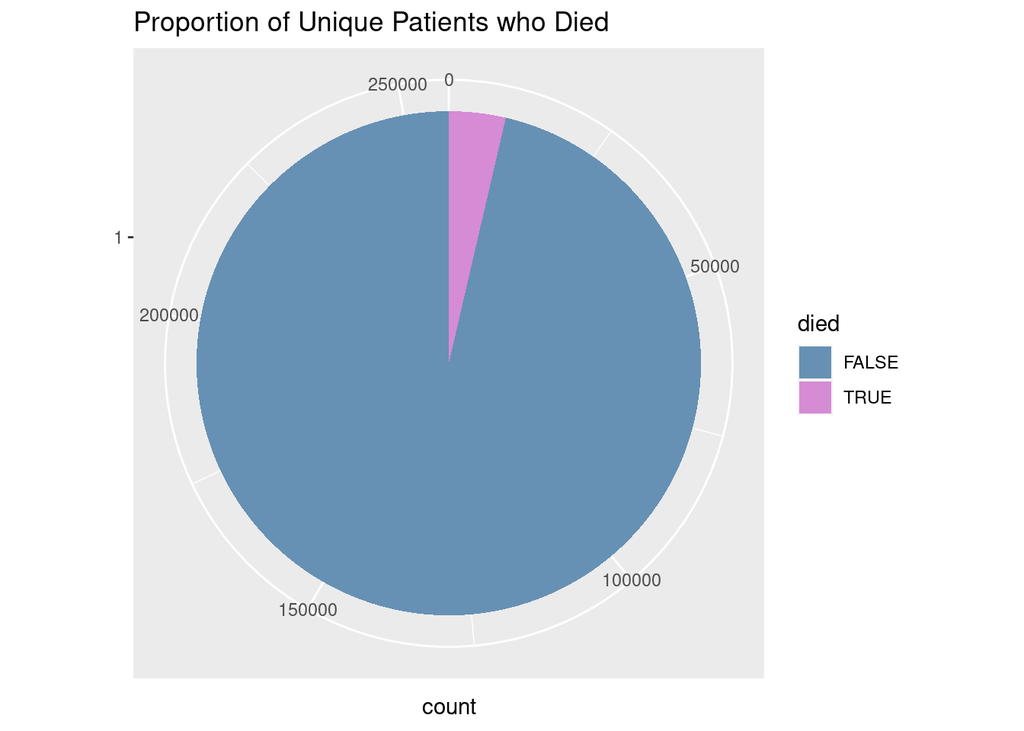

```r
admissions %>%
  group_by(subject_id) %>%
  count(died = sum(!(is.na(deathtime))) > 0) %>%
  ggplot(aes(x = factor(1), fill = died)) +
  geom_bar(width = 1) +
  coord_polar("y") +
  labs(title = "Proportion of Unique Patients who Died", x = NULL) +
  scale_fill_manual(values = c("#6691b4", "#d68bd5"))
```

Fortunately, the vast majority of patients are not recorded as having died during any of their admissions.

## Q5. `patient` data

Explore `patients.csv.gz` (https://mimic-iv.mit.edu/docs/datasets/core/patients/) and summarize following variables using appropriate numerics and graphs:

- `gender`
- `anchor_age` (explain pattern you see)

### Solution

First, read in the data and inspect:

```r
patients <- read_csv(str_c(mimic_path, "/core/patients.csv.gz"))


patients %>%
  print(width = Inf)
```

```
## # A tibble: 383,220 x 6
##    subject_id gender anchor_age anchor_year anchor_year_group dod
##         <dbl> <chr>       <dbl>       <dbl> <chr>             <lgl>
##  1   10002723 F               0        2128 2017 - 2019       NA
##  2   10003939 M               0        2184 2008 - 2010       NA
##  3   10004222 M               0        2161 2014 - 2016       NA
##  4   10005325 F               0        2154 2011 - 2013       NA
##  5   10007338 F               0        2153 2017 - 2019       NA
##  6   10008101 M               0        2142 2008 - 2010       NA
##  7   10009872 F               0        2168 2014 - 2016       NA
##  8   10011333 F               0        2132 2014 - 2016       NA
##  9   10011879 M               0        2158 2014 - 2016       NA
## 10   10012663 F               0        2171 2011 - 2013       NA
## # … with 383,210 more rows
```

#### Gender

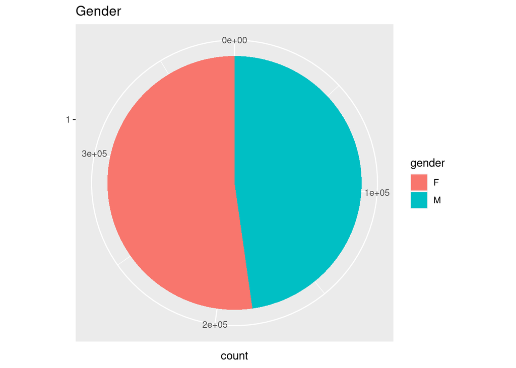

```r
patients %>%
  ggplot(aes(x = factor(1), fill = gender)) +
  geom_bar(width=1) +
  coord_polar("y") +
  labs(title = "Gender", x = NULL)
```

I would have expected a 50/50 split, but there are more women admitted than men. Perhaps childbirth and pregnancy-related visits are part of the explanation.

#### Anchor Age

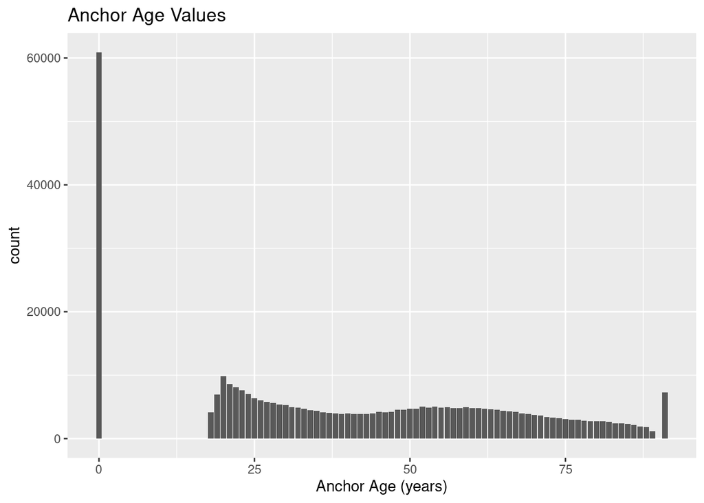

```r
patients %>%
  ggplot() +
  geom_bar(aes(anchor_age)) +
  labs(title = "Anchor Age Values", x = "Anchor Age (years)")
```

There is a huge spike at 0, and then no observations until age 18. I have two theories: one is that the age of minors is not recorded, to protect privacy. Instead, they might be coded as having age “0.” After age 18, the ages appear to be coded as normal. The other theory is that the data only contains adults, but “0” represents unknown/unavailable values.There is also another spike at the upper end, at 91 years old. I suspect that anyone aged 91+ is coded as being 91, for some reason.

I’m curious about the people with age coded as 0 so decided to look at admissions data for those individuals.

```r
ids <- patients %>%
  filter(anchor_age == 0) %>%
  select(subject_id) %>%
  .$subject_id


age_0 <- admissions %>%
  filter(subject_id %in% ids)

age_0 %>%
  count(marital_status, admission_location, admission_type) %>%
  arrange(desc(n))
```

```
## # A tibble: 35 x 4
##    marital_status admission_location     admission_type        n
##    <chr>          <chr>                  <chr>             <int>
##  1 <NA>           <NA>                   ELECTIVE          54358
##  2 SINGLE         <NA>                   ELECTIVE           6008
##  3 <NA>           PHYSICIAN REFERRAL     DIRECT EMER.        555
##  4 <NA>           TRANSFER FROM HOSPITAL URGENT              227
##  5 SINGLE         TRANSFER FROM HOSPITAL URGENT              126
##  6 SINGLE         PHYSICIAN REFERRAL     DIRECT EMER.        109
##  7 <NA>           PHYSICIAN REFERRAL     OBSERVATION ADMIT    95
##  8 <NA>           <NA>                   URGENT               53
##  9 SINGLE         PHYSICIAN REFERRAL     OBSERVATION ADMIT    16
## 10 MARRIED        <NA>                   ELECTIVE             15
## # … with 25 more rows
```

```r
rm(age_0)
```

## Q6. Lab results

`labevents.csv.gz` (https://mimic-iv.mit.edu/docs/datasets/hosp/labevents/) contains all laboratory measurements for patients.

We are interested in the lab measurements of creatinine (50912), potassium (50971), sodium (50983), chloride (50902), bicarbonate (50882), hematocrit (51221), white blood cell count (51301), glucose (50931), magnesium (50960), calcium (50893), and lactate (50813). Find the `itemid`s of these lab measurements from `d_labitems.csv.gz` and retrieve a subset of `labevents.csv.gz` only containing these items.

### Solution

This question ended up being really tricky, since the `labevents.csv.gz` file is so large.

```bash
zcat /usr/203b-data/mimic-iv/hosp/labevents.csv.gz | wc -l
```

The file has 122,289,829 lines. Trying to read this in caused RStudio to crash. Thus, a filtered version of the file was created by Dr. Zhou.

```bash
zcat /usr/203b-data/mimic-iv-derived-data/labevents_filtered_itemid.csv.gz |
  wc -l
```

This filtered file has 30,773,355 lines and contains only the variables of interest. However, even this file ended up being difficult to work with.

#### The process I would have used for this problem

Due to the technical issues described above, it was not possible to complete the problem as originally assigned. However, below is the code that could have been used to find the `itemids` for the lab measurements of interest, and to filter the data to contain only those measurements.

First, load the dictionary file, which has information about the various lab measurements:

```r
labcodes <- read_csv(str_c(mimic_path, "/hosp/d_labitems.csv.gz")) %>%
  print(width = Inf)
```

```
## # A tibble: 1,625 x 5
##    itemid label                     fluid            category   loinc_code
##     <dbl> <chr>                     <chr>            <chr>      <chr>
##  1  51898 <NA>                      Other Body Fluid Chemistry  <NA>
##  2  51532 11-Deoxycorticosterone    Blood            Chemistry  <NA>
##  3  51952 17-Hydroxycorticosteroids Urine            Chemistry  <NA>
##  4  51953 17-Ketosteroids, Urine    Urine            Chemistry  <NA>
##  5  52063 24 Hr                     Blood            Hematology <NA>
##  6  51066 24 hr Calcium             Urine            Chemistry  <NA>
##  7  51067 24 hr Creatinine          Urine            Chemistry  <NA>
##  8  51068 24 hr Protein             Urine            Chemistry  <NA>
##  9  50853 25-OH Vitamin D           Blood            Chemistry  <NA>
## 10  51533 3t                        Blood            Chemistry  <NA>
## # … with 1,615 more rows
```

Search for key terms in the `label` column to find the lab measurement of interest. For example, creatinine:

```r
creatinine_items <- labcodes %>%
  filter(str_detect(label, regex("Creatinine", ignore_case = TRUE))) %>%
  print()
```

```
## # A tibble: 20 x 5
##    itemid label                          fluid               category loinc_code
##     <dbl> <chr>                          <chr>               <chr>    <chr>
##  1  51067 24 hr Creatinine               Urine               Chemist… <NA>
##  2  51070 Albumin/Creatinine, Urine      Urine               Chemist… 14958-3
##  3  51958 Amylase/Creatinine Clearance   Urine               Chemist… <NA>
##  4  51073 Amylase/Creatinine Ratio, Uri… Urine               Chemist… <NA>
##  5  50912 Creatinine                     Blood               Chemist… 2160-0
##  6  52541 Creatinine                     Blood               Chemist… <NA>
##  7  50841 Creatinine, Ascites            Ascites             Chemist… <NA>
##  8  51972 Creatinine, Blood              Urine               Chemist… <NA>
##  9  51032 Creatinine, Body Fluid         Other Body Fluid    Chemist… <NA>
## 10  51080 Creatinine Clearance           Urine               Chemist… <NA>
## 11  51785 Creatinine, CSF                Cerebrospinal Fluid Chemist… <NA>
## 12  51021 Creatinine, Joint Fluid        Joint Fluid         Chemist… <NA>
## 13  51052 Creatinine, Pleural            Pleural             Chemist… <NA>
## 14  51081 Creatinine, Serum              Urine               Chemist… <NA>
## 15  51932 Creatinine, Stool              Stool               Chemist… <NA>
## 16  51082 Creatinine, Urine              Urine               Chemist… 2161-8
## 17  52019 Creatinine, Whole Blood        Blood               Blood G… <NA>
## 18  51099 Protein/Creatinine Ratio       Urine               Chemist… 2890-2
## 19  51995 Urine  Creatinine              Urine               Chemist… <NA>
## 20  51106 Urine Creatinine               Urine               Chemist… <NA>
```

There are a lot of creatinine related measurements, and we probably don’t need to keep most of them (especially given the memory constraints). We can determine which creatinine measurement seems most relevant by tabulating the number of times each version appears in the `labevents` data.

First we create a vector of all `itemid` values associated with creatinine:

```r
creatinine_ids <- creatinine_items %>%
  .$itemid %>%
  print()
```

```
##  [1] 51067 51070 51958 51073 50912 52541 50841 51972 51032 51080 51785 51021
## [13] 51052 51081 51932 51082 52019 51099 51995 51106
```

Assuming the `labevents` file had been successfully read into a tibble called `labs`, we can now see which creatinine `itemid` appers most frequently. The following code filters to only the lab events related to creatinine, counts the times each `itemid` appears, orders from highest to lowest count, and then saves and prints the top occuring `itemid`. For creatinine, this is 50912.

```r
top_creatinine_id <- labs %>%
  filter(itemid %in% creatinine_ids) %>%
  count(itemid) %>%
  arrange(desc(n)) %>%
  slice(1) %>%
  .$itemid %>%
  print()
```

This process could be repeated for the other requested lab items. However, since the full `labevents` file could not be read in easily, Dr. Zhou provided the most frequently used `itemid` for the measurements. These are displayed below:

```r
lab_ids <- labcodes %>%
  filter(itemid %in% c("50912", "50971", "50983", "50902", "50882", "51221",
                      "51301", "50931", "50960", "50893", "50813")) %>%
  select(itemid, label) %>%
  print()
```

```
## # A tibble: 11 x 2
##    itemid label
##     <dbl> <chr>
##  1  50882 Bicarbonate
##  2  50893 Calcium, Total
##  3  50902 Chloride
##  4  50912 Creatinine
##  5  50931 Glucose
##  6  51221 Hematocrit
##  7  50813 Lactate
##  8  50960 Magnesium
##  9  50971 Potassium
## 10  50983 Sodium
## 11  51301 White Blood Cells
```

The `labs` data could then be filtered down to only these measurements of interest.

```r
labs <- labs %>%
  filter(itemid %in% lab_ids$itemid) %>%
  print()
```

#### Reading in the filtered file

Dr. Zhou conducted the above steps to obtain the list of `itemid` values of interest. Then, using `awk` in bash, he filtered only rows with the `itemid` values of interest, and kept only the variables of interest.

I read in the resulting filtered dataset and saved it using the following code:

```r
derived_data_path <- "/usr/203b-data/mimic-iv-derived-data"

if(!file.exists("labevents_filtered.csv.gz")) {
    labevents_tble <- fread(str_c(derived_data_path,
                                  "/labevents_filtered_itemid.csv.gz"),
                          header = FALSE,
                          col.names = c("subject_id",
                                        "hadm_id",
                                        "itemid",
                                        "charttime",
                                        "valuenum"),
                          nThread = 4) %>%
    as_tibble() %>%
    mutate_at(c("subject_id", "hadm_id", "itemid"), as.numeric) %>%
    mutate(charttime = ymd_hms(charttime))

    labevents_tble %>%
      fwrite("labevents_filtered.csv.gz", nThread = 4)
}
```

Note that `charttime` needed to be converted to a date variable, since `fread` was parsing it as a character variable.

The below code can be uncommented to read in the data.

```r
#labs <- fread("labevents_filtered.csv.gz", nThread = 1)
```

Since memory is an issue, I remove unnecessary data from the environment, such as the full lab codes dictionary and the demonstration data frames for creatinine.

```r
rm(labcodes)
rm(creatinine_items)
rm(creatinine_ids)
```

## Q7. Vitals from chartered events

We are interested in the vitals for ICU patients: heart rate, mean and systolic blood pressure (invasive and noninvasive measurements combined), body temperature, SpO2, and respiratory rate. Find the `itemid`s of these vitals from `d_items.csv.gz` and retrieve a subset of `chartevents.csv.gz` only containing these items.

`chartevents.csv.gz` (https://mimic-iv.mit.edu/docs/datasets/icu/chartevents/) contains all the charted data available for a patient. During their ICU stay, the primary repository of a patient’s information is their electronic chart. The `itemid` variable indicates a single measurement type in the database. The `value` variable is the value measured for `itemid`.

`d_items.csv.gz` (https://mimic-iv.mit.edu/docs/datasets/icu/d_items/) is the dictionary for the `itemid` in `chartevents.csv.gz`.

### Solution

As with `labevents.csv.gz`, the `chartevents.csv.gz` file is massive.

```bash
zcat /usr/203b-data/mimic-iv/icu/chartevents.csv.gz | wc -l
```

The original file has 327,363,275 lines and can not be read into RStudio easily. Thus, a filtered version of the file was created by Dr. Zhou.

```bash
zcat /usr/203b-data/mimic-iv-derived-data/chartevents_filtered_itemid.csv.gz |
  wc -l
```

The filtered file has 30,095,996 lines and is a bit easier to work with, but it still has caused me issues.

#### The process I would have used

As before, the problem could not be completed as initially intended. However, a similar process to that described in Question 6 would have been used to get the final filtered version of the dataset.

First, read in the dictionary file for chart items:

```r
chart_codes <- read_csv(str_c(mimic_path, "/icu/d_items.csv.gz"))
```

Search for key terms in the `label` column to find the lab measurement of interest. For example, the following code can be used to to search for each measurement of interest, view the corresponding chart items, and get a vector of `itemid` values:

```r
measurements <- c("heart rate", "blood pressure mean", "systolic",
                  "temperature", "SpO2", "respiratory rate")

for (item in measurements) {
  chart_codes %>%
    filter(str_detect(label, regex(item, ignore_case = T))) %>%
    print()
}
```

We can inspect the output and choose which measurement seems the most reasonable to keep However, if there is any doubt about which `itemid` to use, we use a similar process to what was done in Q6.

My best guesses at the appropriate codes are as follows. I tried to choose the most general form of each measurement, but I would want to verify some of them (blood pressure, Sp02) using the steps outlined in Question 6:

| Measurement | `itemid` |
| --- | --- |
| Heart Rate | 220045 |
| Blood Pressure Mean (invasive) | 220052 |
| Blood Pressure Mean (noninvasive) | 220181 |
| Systolic Blood Pressure | 220179 |
| Body Temperature (F) | 223761 |
| Sp02 Forehead Sensor | 229862 |
| Respiratory Rate | 220210 |

Once this process has been repeated for all measurements of interest, and desired `itemid` values have been saved into vector `top_ids`, the `chart_events` data can be filtered to contain only the subset of desired measurements.

```r
chart_events <- chart_events %>%
  filter(itemid %in% top_ids) %>%
  print()
```

#### Reading in the filtered file

As with the `labevents` data, Dr. Zhou did the steps outlined above but used `awk` to select only the necessary columns and rows of the `chartevents` data. This pre-filtered file, called `chartevents_filtered.csv.gz`, was read in and saved using the following code:

```r
if(!file.exists("chartevents_filtered.csv.gz")) {
    chartevents_tble <- fread(str_c(derived_data_path,
                                    "/chartevents_filtered_itemid.csv.gz"),
                          header = FALSE,
                          col.names = c("subject_id",
                                       "hadm_id",
                                       "stay_id",
                                       "charttime",
                                       "itemid",
                                       "valuenum"),
                          nThread = 4) %>%
    as_tibble() %>%
    mutate_at(c("subject_id", "hadm_id", "stay_id", "itemid"), as.numeric) %>%
    mutate(charttime = ymd_hms(charttime)) %>%
    print(width = Inf)

    chartevents_tble %>%
      fwrite("chartevents_filtered.csv.gz", nThread = 4)

}
```

Can uncomment the following code to read this in.

```r
#chart_events <- fread("chartevents_filtered.csv.gz", nThread = 1)
```

Even this reduced file caused RStudio to crash frequently, so I filtered further in Q8. This final version of the data can be read in here:

```r
chart_events <- fread("chartevents_filtered_icustays.csv.gz", nThread = 1)
```

I want to see what codes Dr. Zhou selected.

```r
chart_events %>%
  group_by(itemid) %>%
  count()
```

```
## # A tibble: 7 x 2
## # Groups:   itemid [7]
##   itemid       n
##    <int>   <int>
## 1 220045 5734767
## 2 220050 2209687
## 3 220052 2218618
## 4 220179 2958294
## 5 220181 2956016
## 6 220210 5662763
## 7 223761 1135193
```

The codes are: 220045, 220050, 220052, 220179, 220181, 220210, 223761. His choices are close, but not identical to mine. Since I read in his version of the data, I’ll use his codes moving forward.

I want to see what these correspond to and save the results.

```r
chart_ids <- chart_codes %>%
  filter(itemid %in% c("220045", "220050", "220052",
                       "220179", "220181", "220210", "223761")) %>%
  select(itemid, label) %>%
  print()
```

```
## # A tibble: 7 x 2
##   itemid label
##    <dbl> <chr>
## 1 220045 Heart Rate
## 2 220050 Arterial Blood Pressure systolic
## 3 220052 Arterial Blood Pressure mean
## 4 220179 Non Invasive Blood Pressure systolic
## 5 220181 Non Invasive Blood Pressure mean
## 6 220210 Respiratory Rate
## 7 223761 Temperature Fahrenheit
```

Remove unnecessary data from environment:

```r
rm(chart_codes)
rm(measurements)
```

## Q8. Putting things together

Let us create a tibble for all ICU stays, where rows are

- first ICU stay of each unique patient
- adults (age at admission > 18)

and columns contain at least following variables

- all variables in `icustays.csv.gz`
- all variables in `admission.csv.gz`
- all variables in `patients.csv.gz`
- first lab measurements during ICU stay
- first vitals measurement during ICU stay
- an indicator variable whether the patient died within 30 days of hospital admission

### Solution

The “base” data for this problem is the ICU data, which I stored in the data frame `icu_stays` in Question 3. The first goal is to keep only the first ICU stay for each patient, which can be done by grouping by `subject_id` and then keeping only the first chronological stay.

```r
full_icu <- icu_stays %>%
  group_by(subject_id) %>%
  filter(rank(intime) == 1) %>%
  ungroup()
```

Next, we join to the `admissions` (created in Q4) and `patients` (from Q5): The ICU stay can be joined to `admissions` by `hadm_id` (we also use `subject_id`, but it’s not strictly necessary), and can be joined to `patients` by `subject_id`.

```r
full_icu <- full_icu %>%
  left_join(admissions, by = c("hadm_id", "subject_id")) %>%
  left_join(patients, by = c("subject_id")) %>%
  print()
```

```
## # A tibble: 50,048 x 26
##    subject_id hadm_id stay_id first_careunit last_careunit intime
##         <dbl>   <dbl>   <dbl> <chr>          <chr>         <dttm>
##  1   13713711  2.58e7  3.64e7 Trauma SICU (… Trauma SICU … 2157-09-15 15:30:00
##  2   13173210  2.23e7  3.82e7 Coronary Care… Coronary Car… 2178-02-12 17:13:50
##  3   10213765  2.85e7  3.98e7 Trauma SICU (… Trauma SICU … 2113-04-10 14:11:00
##  4   17530304  2.18e7  3.58e7 Trauma SICU (… Trauma SICU … 2129-03-21 07:09:00
##  5   16766597  2.12e7  3.93e7 Trauma SICU (… Trauma SICU … 2115-07-11 23:15:59
##  6   17684317  2.87e7  3.70e7 Trauma SICU (… Trauma SICU … 2148-04-14 22:03:00
##  7   15693895  2.12e7  3.48e7 Surgical Inte… Surgical Int… 2147-06-02 23:31:46
##  8   13859862  2.50e7  3.19e7 Medical/Surgi… Medical/Surg… 2152-04-07 01:43:35
##  9   12200371  2.73e7  3.23e7 Medical/Surgi… Medical/Surg… 2146-02-18 18:14:25
## 10   13307171  2.11e7  3.80e7 Neuro Stepdown Neuro Stepdo… 2145-11-22 00:54:00
## # … with 50,038 more rows, and 20 more variables: outtime <dttm>, los <dbl>,
## #   admittime <dttm>, dischtime <dttm>, deathtime <dttm>, admission_type <chr>,
## #   admission_location <chr>, discharge_location <chr>, insurance <chr>,
## #   language <chr>, marital_status <chr>, ethnicity <chr>, edregtime <dttm>,
## #   edouttime <dttm>, hospital_expire_flag <dbl>, gender <chr>,
## #   anchor_age <dbl>, anchor_year <dbl>, anchor_year_group <chr>, dod <lgl>
```

Now, we want to keep only adults. Since the only age recorded is the age during the “anchor year”, we need to calculate what the age at time of the admission was. We do this by finding how many years have passed since the `anchor_year` and adding those to the `anchor_age`. Then, we filter such that only adults (> 18) are kept.

```r
full_icu <- full_icu %>%
  mutate(age_at_adm = year(admittime) - anchor_year + anchor_age) %>%
  filter(age_at_adm > 18) %>%
  print()
```

```
## # A tibble: 49,971 x 27
##    subject_id hadm_id stay_id first_careunit last_careunit intime
##         <dbl>   <dbl>   <dbl> <chr>          <chr>         <dttm>
##  1   13713711  2.58e7  3.64e7 Trauma SICU (… Trauma SICU … 2157-09-15 15:30:00
##  2   13173210  2.23e7  3.82e7 Coronary Care… Coronary Car… 2178-02-12 17:13:50
##  3   10213765  2.85e7  3.98e7 Trauma SICU (… Trauma SICU … 2113-04-10 14:11:00
##  4   17530304  2.18e7  3.58e7 Trauma SICU (… Trauma SICU … 2129-03-21 07:09:00
##  5   16766597  2.12e7  3.93e7 Trauma SICU (… Trauma SICU … 2115-07-11 23:15:59
##  6   17684317  2.87e7  3.70e7 Trauma SICU (… Trauma SICU … 2148-04-14 22:03:00
##  7   15693895  2.12e7  3.48e7 Surgical Inte… Surgical Int… 2147-06-02 23:31:46
##  8   13859862  2.50e7  3.19e7 Medical/Surgi… Medical/Surg… 2152-04-07 01:43:35
##  9   12200371  2.73e7  3.23e7 Medical/Surgi… Medical/Surg… 2146-02-18 18:14:25
## 10   13307171  2.11e7  3.80e7 Neuro Stepdown Neuro Stepdo… 2145-11-22 00:54:00
## # … with 49,961 more rows, and 21 more variables: outtime <dttm>, los <dbl>,
## #   admittime <dttm>, dischtime <dttm>, deathtime <dttm>, admission_type <chr>,
## #   admission_location <chr>, discharge_location <chr>, insurance <chr>,
## #   language <chr>, marital_status <chr>, ethnicity <chr>, edregtime <dttm>,
## #   edouttime <dttm>, hospital_expire_flag <dbl>, gender <chr>,
## #   anchor_age <dbl>, anchor_year <dbl>, anchor_year_group <chr>, dod <lgl>,
## #   age_at_adm <dbl>
```

There are 49,971 unique adults with ICU stays.

Now, we want to merge lab results to this table. However, we only want to keep the first lab result of each type, during the ICU stay.

The filtered `labevents` file is still huge, so now is a convenient time to save a version that keeps only observations that will be used for this final step.

```r
if(!file.exists("labevents_filtered_icustays.csv.gz")) {
  labs %>%
    semi_join(full_icu_tibble, by = c("subject_id", "hadm_id")) %>%
    fwrite("labevents_filtered_icustays.csv.gz", nThread = 4)
}
```

The following code can be used to read in this smaller `labevents` data:

```r
labs <- fread("labevents_filtered_icustays.csv.gz", nThread = 1)
```

Now, the `labevents` data can be joined with the combined `icu_stays`, `patients`, and `admissions` data frame. We first join the labs to the ICU data to get the `intime` for the patient’s ICU stay. We only want to keep lab measurements that happened after the beginning of this stay. Then, we group and arrange such that each type of measurement for each patient is listed chronologically. We use `slice_head` to keep only the first of each measurement type. Then, we join all of the remaining lab data to the merged ICU/patients/admissions data and give the variables for the lab measurements an informative name.

```r
full_icu_labs <- labs %>%
  semi_join(full_icu, by = c("subject_id", "hadm_id")) %>%
  left_join(select(full_icu, subject_id, hadm_id, intime),
                   by = c("subject_id", "hadm_id")) %>%
  filter(charttime >= intime) %>%
  group_by(subject_id, itemid) %>%
  arrange(charttime, .by_group = TRUE) %>%
  slice_head(n = 1) %>%
  select(-charttime, -intime) %>%
  spread(key = itemid, value = valuenum) %>%
  right_join(full_icu, by = c("subject_id", "hadm_id")) %>%
  ungroup() %>%
  rename_at(vars(as.character(lab_ids$itemid)), ~lab_ids$label) %>%
  print()
```

```
## # A tibble: 49,971 x 38
##    subject_id hadm_id Lactate Bicarbonate `Calcium, Total` Chloride Creatinine
##         <dbl>   <dbl>   <dbl>       <dbl>            <dbl>    <dbl>      <dbl>
##  1   10000032  2.91e7    NA            21              9.3      102        0.5
##  2   10000980  2.69e7    NA            23              9.2      103        2.2
##  3   10001217  2.46e7    NA            23              8.2      104        0.4
##  4   10001725  2.56e7    NA            24              9.1      106        0.8
##  5   10001884  2.62e7     1.5          33              9.8       96        1.1
##  6   10002013  2.36e7     3.3          23             NA        109        1.1
##  7   10002155  2.38e7    NA            25              8.8      106        0.9
##  8   10002223  2.25e7    NA            26              8.7      102        0.8
##  9   10002428  2.87e7     1.6          20              7.4       98        0.8
## 10   10002443  2.13e7     1.7          20              7.6      101        0.8
## # … with 49,961 more rows, and 31 more variables: Glucose <dbl>,
## #   Magnesium <dbl>, Potassium <dbl>, Sodium <dbl>, Hematocrit <dbl>, `White
## #   Blood Cells` <dbl>, stay_id <dbl>, first_careunit <chr>,
## #   last_careunit <chr>, intime <dttm>, outtime <dttm>, los <dbl>,
## #   admittime <dttm>, dischtime <dttm>, deathtime <dttm>, admission_type <chr>,
## #   admission_location <chr>, discharge_location <chr>, insurance <chr>,
## #   language <chr>, marital_status <chr>, ethnicity <chr>, edregtime <dttm>,
## #   edouttime <dttm>, hospital_expire_flag <dbl>, gender <chr>,
## #   anchor_age <dbl>, anchor_year <dbl>, anchor_year_group <chr>, dod <lgl>,
## #   age_at_adm <dbl>
```

```r
rm(labs)
```

We’ll follow a similar pattern for chart events. First, it’s convenient to save a version of the chart data with only adults in the ICU data.

```r
if(!file.exists("chartevents_filtered_icustays.csv.gz")) {
  chart_events %>%
    semi_join(full_icu_tibble, by = c("subject_id", "hadm_id")) %>%
    fwrite("chartevents_filtered_icustays.csv.gz", nThread = 4)
}
```

The below code can be uncommented to read in the chart events data, if needed. However, this file was already read-in during Question 7.

```r
#chart_events <- fread("chartevents_filtered_icustays.csv.gz", nThread = 1)
```

Now, we repeat the exact same process as above. However, since `chart_events` also has the `stay_id` variable, we will also use this as an identifier in the joins.

```r
full_icu_chart <- chart_events %>%
  semi_join(full_icu, by = c("subject_id", "stay_id", "hadm_id")) %>%
  left_join(select(full_icu, subject_id, stay_id, intime),
                   by = c("subject_id", "stay_id")) %>%
  filter(charttime >= intime) %>%
  group_by(subject_id, itemid) %>%
  arrange(charttime, .by_group = TRUE) %>%
  slice_head(n = 1) %>%
  select(-charttime, -intime) %>%
  spread(key = itemid, value = valuenum) %>%
  right_join(full_icu, by = c("subject_id", "stay_id", "hadm_id")) %>%
  ungroup() %>%
  rename_at(vars(as.character(chart_ids$itemid)), ~chart_ids$label) %>%
  print()
```

```
## # A tibble: 49,971 x 34
##    subject_id hadm_id stay_id `Heart Rate` `Arterial Blood… `Arterial Blood…
##         <dbl>   <dbl>   <dbl>        <dbl>            <dbl>            <dbl>
##  1   10000032  2.91e7  3.75e7           91               NA               NA
##  2   10000980  2.69e7  3.67e7           77               NA               NA
##  3   10001217  2.46e7  3.03e7           86               NA               NA
##  4   10001725  2.56e7  3.75e7           55               NA               NA
##  5   10001884  2.62e7  3.18e7           38               NA               NA
##  6   10002013  2.36e7  3.71e7           80              134               94
##  7   10002155  2.38e7  3.46e7           68              115               82
##  8   10002223  2.25e7  3.99e7          100               NA               NA
##  9   10002428  2.87e7  3.20e7          124               NA               NA
## 10   10002443  2.13e7  3.52e7           81               NA               NA
## # … with 49,961 more rows, and 28 more variables: `Non Invasive Blood Pressure
## #   systolic` <dbl>, `Non Invasive Blood Pressure mean` <dbl>, `Respiratory
## #   Rate` <dbl>, `Temperature Fahrenheit` <dbl>, first_careunit <chr>,
## #   last_careunit <chr>, intime <dttm>, outtime <dttm>, los <dbl>,
## #   admittime <dttm>, dischtime <dttm>, deathtime <dttm>, admission_type <chr>,
## #   admission_location <chr>, discharge_location <chr>, insurance <chr>,
## #   language <chr>, marital_status <chr>, ethnicity <chr>, edregtime <dttm>,
## #   edouttime <dttm>, hospital_expire_flag <dbl>, gender <chr>,
## #   anchor_age <dbl>, anchor_year <dbl>, anchor_year_group <chr>, dod <lgl>,
## #   age_at_adm <dbl>
```

```r
rm(chart_events)
```

Now we now have two frames: `full_icu_labs` and `full_icu_chart`. The `patient`, `admissions`, and `icu` data are common to both, but one contains lab events, and the other has chart events. We can now join by all common variables.

```r
final_icu_data <- full_icu_labs %>%
  left_join(full_icu_chart) %>%
  as_tibble()
```

Some intermediate data frames are no longer needed and can be removed.

```r
rm(full_icu_chart)
rm(full_icu_labs)
rm(full_icu)
```

```r
final_icu_data <- final_icu_data %>%
  mutate(time_to_death = as.duration(deathtime - intime),
         death_in_30 = ifelse(is.na(time_to_death) | time_to_death > ddays(30),
                                    FALSE, TRUE)) %>%
  select(-time_to_death)
```

How many people die within 30 days?

```r
final_icu_data %>%
  filter(death_in_30) %>%
  count()
```

```
## # A tibble: 1 x 1
##       n
##   <int>
## 1  4974
```

Of the 49,971 admissions, 4974 had an outcome of death within 30 days.

How many patients die, but after 30 days?

```r
final_icu_data %>%
  filter(!is.na(deathtime) & !death_in_30) %>%
  count()
```

```
## # A tibble: 1 x 1
##       n
##   <int>
## 1   201
```

201 patients die after the 30 day mark.

Here is the structure of the final tibble:

```r
final_icu_data %>%
  print(width = Inf)
```

```
## # A tibble: 49,971 x 46
##    subject_id  hadm_id Lactate Bicarbonate `Calcium, Total` Chloride Creatinine
##         <dbl>    <dbl>   <dbl>       <dbl>            <dbl>    <dbl>      <dbl>
##  1   10000032 29079034    NA            21              9.3      102        0.5
##  2   10000980 26913865    NA            23              9.2      103        2.2
##  3   10001217 24597018    NA            23              8.2      104        0.4
##  4   10001725 25563031    NA            24              9.1      106        0.8
##  5   10001884 26184834     1.5          33              9.8       96        1.1
##  6   10002013 23581541     3.3          23             NA        109        1.1
##  7   10002155 23822395    NA            25              8.8      106        0.9
##  8   10002223 22494570    NA            26              8.7      102        0.8
##  9   10002428 28662225     1.6          20              7.4       98        0.8
## 10   10002443 21329021     1.7          20              7.6      101        0.8
##    Glucose Magnesium Potassium Sodium Hematocrit `White Blood Cells`  stay_id
##      <dbl>     <dbl>     <dbl>  <dbl>      <dbl>               <dbl>    <dbl>
```

[output cut: 143 more lines]